# Pack dynamics data exploration and other potential systems

# Wolves

## YNP population

Mange was introduced in 2007. Are there any differences in pack dynamics pre- and post-2007?

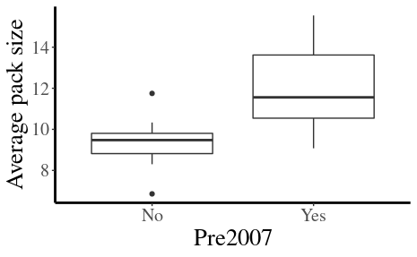

From the above figure, it does look liek the average group size dropped after 2007. Looking at the time series, the popuation also dropped. Of course cause and effect here is unclear but the pattern in compelling.

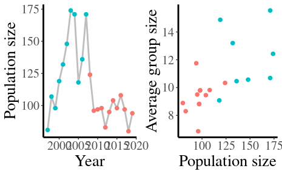

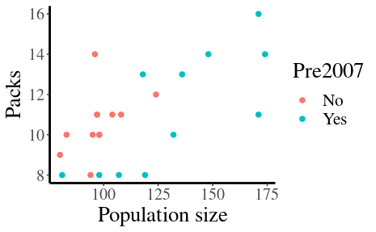

```r
ggplot(data=YSdata, aes(x=Size, y=Packs)) +
  #geom_line(size=1, col="gray") +
  #geom_smooth(se=F, col="grey") +
  geom_point(size=2, aes(col=Pre2007)) +
  ylab("Packs") + xlab("Population size")
```

```r
powlaw1 <- function(X, a, b, c) {
  exp(b)*X^c + a
}
powlaw2 <- function(X, b, c) {
  exp(b)*X^c
}

YNP1.fit <- nls(Packs ~ powlaw1(AdultsYearlings, a, b, c), start=list(a=0, b=0.15, c=0.5), data=YSdata, nls.control(tol=1e-4, maxiter=1e4, warnOnly = TRUE))
YNP2.fit <- nls(Packs ~ powlaw2(AdultsYearlings, b, c), start=list(b=0.15, c=0.5), data=YSdata, nls.control(tol=1e-4, maxiter=1e4, warnOnly = TRUE))

model.sel(list(YNP1.fit, YNP2.fit))
```

```
Model selection table
  (Int) pw1(AdY,a,b,c) pw2(AdY,b,c) family            start df
2     +                           +   (NA)   list(0.15,0.5)  3
1     +              +                (NA) list(0,0.15,0.5)  4
   logLik AICc delta weight
2 -40.853 89.1  0.00  0.757
1 -40.443 91.4  2.27  0.243
Models ranked by AICc(x)
```

```r
coef(YNP2.fit)
```

```
        b         c
0.1034839 0.5295732
```

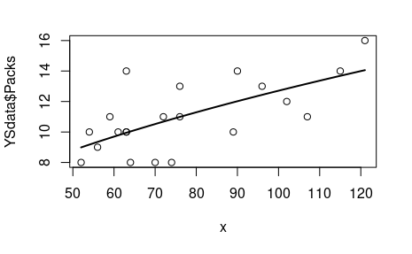

```r
plot(x=x, y=YSdata$Packs)
with(as.list(coef(YNP2.fit)), curve(powlaw2(x, b = b, c=c), lwd = 2, add = TRUE))
```

```r
#lines(pop.pred, mod0$pred, col='red')

#mod0 <- lm(log(Packs) ~ log(Size), data=YSdata)
coef(YNP2.fit)
```

```
        b         c
0.1034839 0.5295732
```

```r
confint(YNP2.fit)
```

```
        2.5%     97.5%
b -1.1627630 1.3616997
c  0.2412019 0.8160367
```

The regression indicates a powerlaw relationship between packs and wolf density with $P=1.1\, W^{0.5}$.

## Scandanavian wolf populations

Data come from Chapron et al 2016 through 2014, then from 2014 from NINA. Will need earlier data… Have some for sweden but not sure if its comparable or the source….

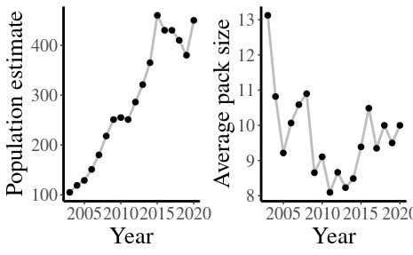

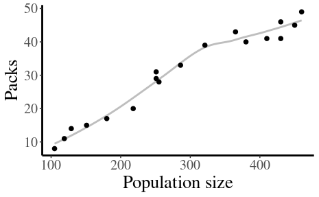

```r
Scan1.fit <- nls(Packs ~ powlaw1(Size, a, b, c), start=list(a=0, b=0.15, c=0.5), data=Scandata, nls.control(tol=1e-4, maxiter=1e4, warnOnly = TRUE))
Scan2.fit <- nls(Packs ~ powlaw2(Size, b, c), start=list(b=0.15, c=0.5), data=Scandata, nls.control(tol=1e-4, maxiter=1e4, warnOnly = TRUE))

model.sel(list(Scan1.fit, Scan2.fit))
```

```
Model selection table
  (Int) pw1(Siz,a,b,c) pw2(Siz,b,c) family            start df
1     +              +                (NA) list(0,0.15,0.5)  4
2     +                           +   (NA)   list(0.15,0.5)  3
   logLik AICc delta weight
1 -40.371 91.8  0.00  0.857
2 -43.844 95.4  3.58  0.143
Models ranked by AICc(x)
```

```r
coef(Scan1.fit)
```

```
          a           b           c
-45.7792452   2.2535162   0.3715054
```

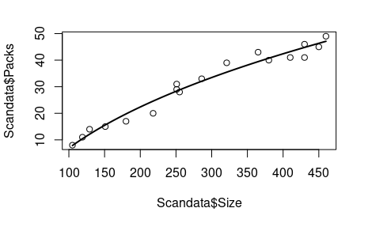

```r
plot(x=Scandata$Size, y=Scandata$Packs)
with(as.list(coef(Scan1.fit)), curve(powlaw1(x, a=a, b = b, c=c), lwd = 2, add = TRUE))
```

```r
#lines(pop.pred, mod0$pred, col='red')

#mod0 <- lm(log(Packs) ~ log(Size), data=YSdata)
coef(Scan1.fit)
```

```
          a           b           c
-45.7792452   2.2535162   0.3715054
```

```r
confint(Scan1.fit)
```

```
step factor 0.000488281 reduced below 'minFactor' of 0.000976562
```

```
        2.5%      97.5%
a         NA -7.2186314
b -1.3395425         NA
c  0.3314951  0.8677547
```

In this case the relationship is $P=9.52\,W^{0.37} - 45.78$.

## Other wolf populations

- Isle Royale
  - Abundances data through [1976](http://npshistory.com/series/science/11/chap2.htm)
  - just two packs through 1976. did a third form later?

# Orca

- Residents (fixed number of groups)
  - PNW pods
  - Canada pods
  - Alaska pods
- Transient (variable number of groups)
  - descriptive study [Baird et al. 1995](https://pdfs.semanticscholar.org/af84/33767d2c2948b479194ec92e084394f882cb.pdf)

# Lions

- Fryxell data (fixed number of groups (i think!))
- Becker data in Zambia?
- Packer et al 1990, Why lions form groups: food is not enough.
  - groups used to forage but also defend young, territory, and carcasses.
  - looks at number of females per group …

# Sticklebacks

- Milinski 1979